# Forecasting Homework #2

#### Introduction

This notebook serves as an interactive document where we try to forecast the U.S. price of Ground Beef.

#### 1) Dataset Description

The Dataset used for forecasting is monthly data from January 1984 to September 2017. The features in this dataset are the following:  
1. Date Variable: Month & Year  
2. Ground beef price: Prices of ground beef during specified dates  
3. $p_t$: Log price of beef  
4. $\pi_t$: Price Inflation of $p_t$

**Important: It is important to note that there was a 0 Ground Beef price value for October 2012, which corresponded to a NA log price and price inflation, as a means to handle this missingness, we have used a linear approximation of this missing value using the imputeTS package with the na.interpolate function**

```r
# Import relevant packages
library(fpp)
library(readxl)
library(ggplot2)
library(imputeTS)
library(xts)
```

```r
# Read dataset
data <- read_excel("BeefPrices.xlsx")
# Convert dataset into time series object
data_ts = ts(data[2:length(data)], start = c(1984, 1), frequency = 12)
```

```
NAs introduced by coercion
```

```r
data_ts = na.interpolation(data_ts)  # impute missing values using a linear interpolation
colnames(data_ts) <- c("Price","Log_Price","Inflation")
# Make sure data imported correctly
head(data_ts)
```

```
         Price Log_Price   Inflation
Jan 1984 1.290 0.2546422  0.03802740
Feb 1984 1.340 0.2926696  0.03802740
Mar 1984 1.308 0.2684993 -0.02417036
Apr 1984 1.331 0.2859305  0.01743129
May 1984 1.301 0.2631332 -0.02279734
Jun 1984 1.269 0.2382292 -0.02490401
```

Now we want to see whether $p_t$ and $\pi_t$ are stationary variables - we can do so by visualizing both features, and plotting their corresponding Autocorrelation Function

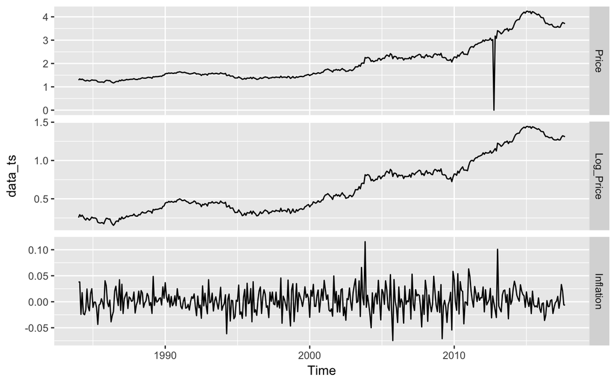

```r
autoplot(data_ts, facets = TRUE) #plot the features
```

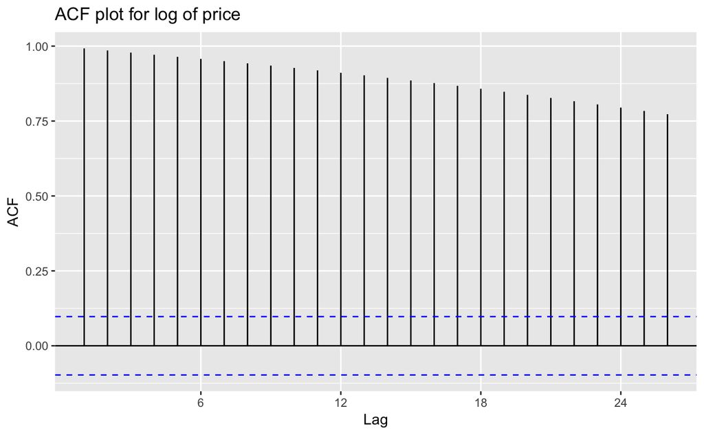

```r
ggAcf(data_ts[,2], main = "ACF plot for log of price")
```

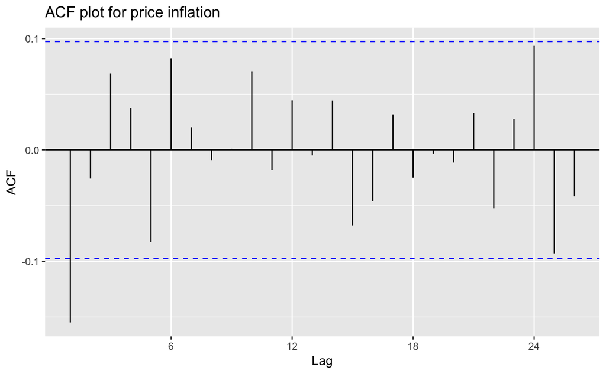

```r
ggAcf(data_ts[,3], main = "ACF plot for price inflation")
```

#### 2) Modeling

##### a) Price $p_t$

*If you wish to go over the details of the models discussed below, please refer to the otexts and handout resources in the course webpage*

Now going back to the plot of $p_t$

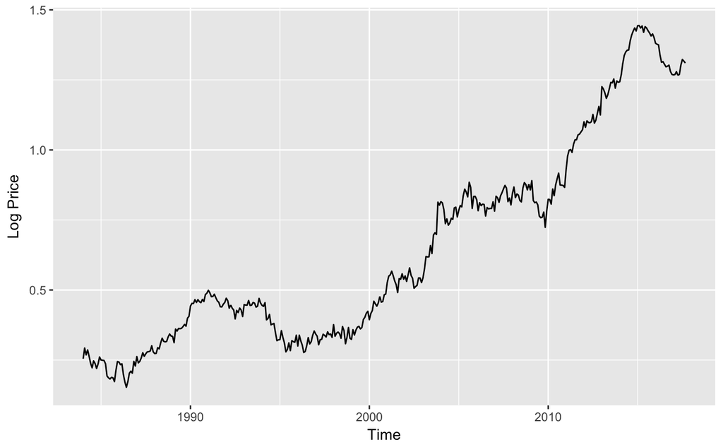

```r
autoplot(data_ts[,"Log_Price"]) + ylab("Log Price") #plot data
```

We can see that the timeseries contains an upward trend component $T_t$ and some seasonal component $S_t$ with varying strenghts. Getting a glance at the data offers good indicators to which models might work and which ones don’t.  
**The exponential smoothing model** tries to capture with a varying degree the effect of the most recent data points with historical data, the exponential smoothing model can be formulated accordingly:  
$\hat{y}_{t+1|t} = \alpha y_t + \alpha(1-\alpha)y_{t-1} + \alpha(1-\alpha)^2y_{t-2} + ...$  
However, the exponential smoothing model is not as adept at modeling the trend and seasonal components present that can be observed in our model.  
**The Holt linear trend method** extends exponential smoothing by adding a trend component to the model presented above, if we summarize the linear component captured by the exponential smoothing model above as $l_t$, we can add a trend component  
$b_t = \beta^*(l_t - l_{t-1}) + (1-\beta*)b_{t-1}$  
This technique better captures the trend component and is hypothetically better suited for the data.  
**The Holt-Winters Model** adds on top of the previously discussed holt model, by adding a seasonal component $s_t$ that captures both the changes in $l_t$ and $b_t$ *(refer to otext page for deeper insight on formula)*. This technique is hypothetically better suited for our problem, becauase it captures both the trend and seasonal components of the log price’s $p_t$ behaviour.

Let’s compare all of these three models on our dataset below:

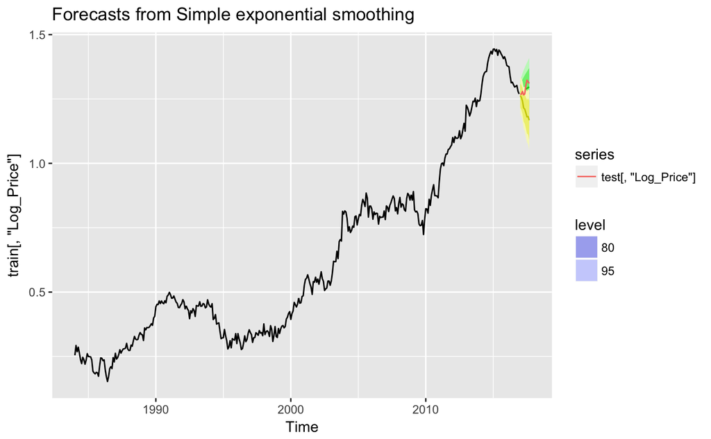

```r
train <- window(data_ts, end = c(2016,12)) # training set being every observation till 2016
test <- window(data_ts, start = c(2017,1)) # test set being all 2017 observations
# Modeling for Price data
fc_ses <- ses(train[,"Log_Price"], h = 9)     # exponential smoothing
fc_holt <- holt(train[,"Log_Price"], h = 9)    # holt linear trend model
fc_hw <- hw(train[,"Log_Price"], h = 9)      # holt-winters model
# Plot the different forecasts
autoplot(fc_ses,colour = TRUE) + autolayer(fc_holt, colour = "green") + autolayer(fc_hw, colour = "yellow") + autolayer(test[,'Log_Price'], colour = TRUE)    # plot all the forecasts against test set
```

Apparently, complex does not always mean better, the Holt model better accurately captures the behavior of our model (green).  
We can try to check the performance of each of these models more formally:

Let’s first check the residuals of each of these models - R allows us to do so with the checkresiduals() command

```
    Ljung-Box test

data:  Residuals from Simple exponential smoothing
Q* = 21.361, df = 22, p-value = 0.4985

Model df: 2.   Total lags used: 24
```

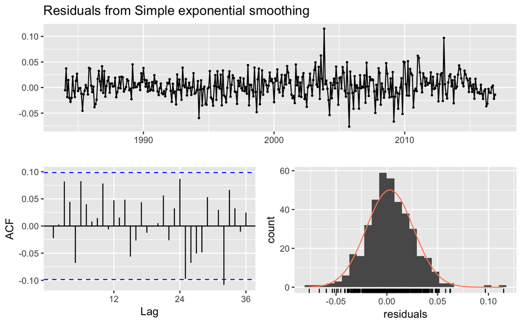

```r
#check residuals for SES model
checkresiduals(fc_ses)
```

```
    Ljung-Box test

data:  Residuals from Holt's method
Q* = 21.427, df = 20, p-value = 0.3724

Model df: 4.   Total lags used: 24
```

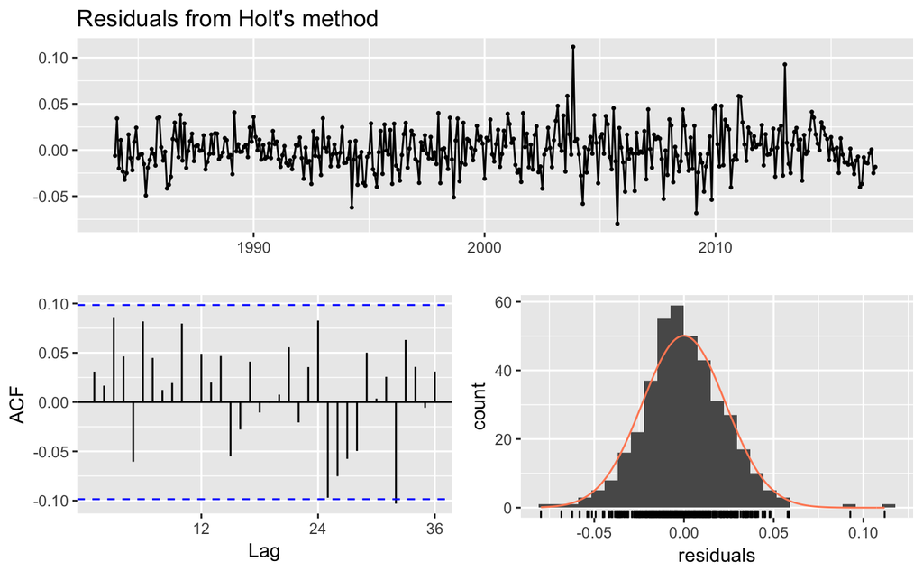

```r
#check residuals for Holt model
checkresiduals(fc_holt)
```

```
    Ljung-Box test

data:  Residuals from Holt-Winters' additive method
Q* = 433.3, df = 8, p-value < 2.2e-16

Model df: 16.   Total lags used: 24
```

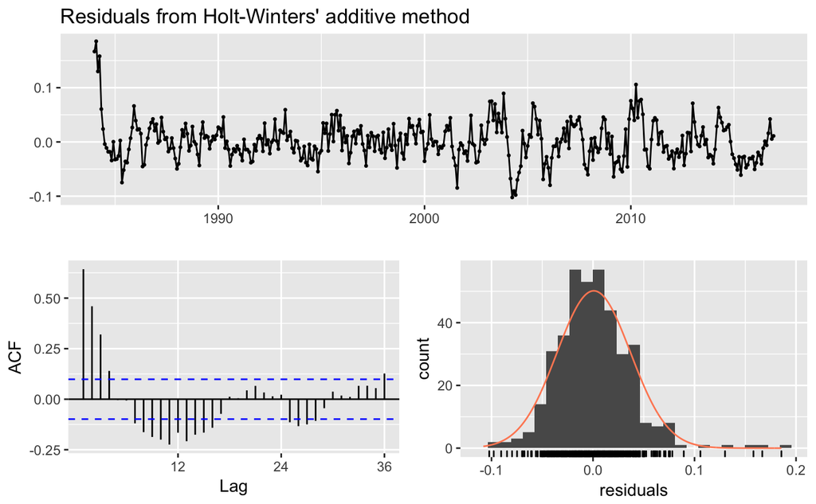

```r
#check residuals for Holt-Winters model
checkresiduals(fc_hw)
```

As we can see, the residuals of both the exponential smoothing model and the holt method are stationary, both with a $p-value > 0.05$ in the Ljung-Box test. However, the Holt-Winter’s additive method does not produce stationary residuals.  
Since all of these models belong to the same family of exponential smoothers, we can compare their $AICc$ scores. In brief, the $AICc$ is a model selection score criterion that evaluates the tradeoff between model accuracy and model complexity - for more information on the $AICc$ score, please refer to this [website](http://www.sciencedirect.com/science/article/pii/S2212977414000064).  
Essentially, the model with the lowest $AICc$ score is the best. It is important to note, that we cannot cross compare different families of models using the $AICc$ score.

```r
list_AICc = list("SES_AICc" = fc_ses$model$aicc, "Holt_AICc" = fc_holt$model$aicc, "HW_AICc" = fc_hw$model$aicc)
print(list_AICc)
```

```
$SES_AICc
[1] -599.6091

$Holt_AICc
[1] -601.7277

$HW_AICc
[1] -223.6441
```

Our hypothesis is confirmed, the holt method provides the best solution.

##### b) ARMA Model on $\pi_t$

###### Note that you can find detailed explanations of the models in the Handouts and Otexts ressources, as well as the [wikipedia page](http://bit.ly/2iRiy55) for $ARIMA(p,d,q)$ models.

It is essential to note that $ARIMA(p,d,q)$ Models are Autoregressive Integrated Moving Average models. Intuitively speaking, without going into the formal mathematical details of each variation of $ARIMA(p,d,q)$ models - $ARIMA(p,d,q)$ models combine the following elements:

1. Autogregressive element with number of time lags decided by $p$
2. An Integrated element which replaced the original feature with the differenced feature and is decided by $d$
3. Moving average element with the order of the moving average being decided by the parameter $q$  
   Hence, when using R, we can model an ARMA model using the Arima() function but we set the $d$ parameter = 0.

Now there are two ways we can go about the modelling task, we can either choose an **iterative approach**, where at each timestamp $t$, we model $y_t$ by leveraging all the information $I_{t-1}$ - practically speaking, this is a rolling forecast, which means at each point in timme in our forecast we update our model.  
On the other hand we can go about the modelling using a direct approach, this means that by creating a model $y_t$ at time stamp $t$, we can predict $h$ timestamps into the future.  
Let’s see both these methodologies in action:

##### Iterative

```
For a multivariate timeseries, specify a seriesname for each timeseries. Defaulting to column names.
```

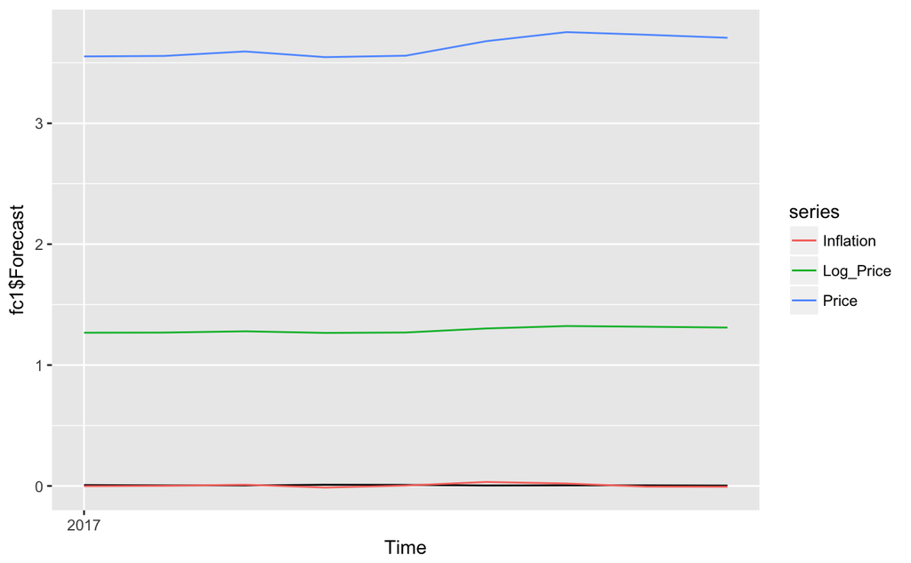

```r
# This function takes in as input our timeseries x, we specify the parameters:
# Forecast Horizon - h
# P,D,Q values for our Arima model
# End date of the train data
# Start date for the test data.
# Column name we want to forecast, in this case it's the "Inflation""
iterative_training <- function(x, h = 1, p = 1, d = 0, q = 1, train_end = c(2016,12), test_start = c(2017,1), colname = "Inflation")
  {
    train <- window(x, end=train_end)          # create training data
    train <- train[,colname]                   # constrain it to inflation variable
    test <- window(x,start= test_start)        # repeat for test data
    test <- test[,colname]
    n <- length(test) - h + 1                  # create the forecast horizon for the iterative algorithm
    fit <- Arima(train, order = c(p,d,q))      # model initial training data using ARMA(1,1)
    fcmat <- matrix(0, nrow=n, ncol=h)         # create an empty time series to be filled up by forecast data

    for(i in 1:n)
      {
      new <- window(x[,colname], end=2016 + (i-1)/12)        # continuously grow training set at each iteration
      refit <- Arima(new, order= c(1,0,1))                   # model on the new training data
      fcmat[i,] <- forecast(refit, h=h)$mean                 # save forecast data
    }
    my_list <- list("Forecast" = ts(fcmat, start = test_start, frequency = 12), "Fit" = fit, "Refit" = refit)
    return(my_list)   # return forecast in a time series object, initial model and refit model
  }
fc1 <- iterative_training(data_ts)     # forecast inflation feature using an iterative one step forecast
autoplot(fc1$Forecast) + autolayer(test)        # plot forecast against test data
```

As we can see, the forecast gravitates towards the mean of the test data, but it doesn’t capture the “jumps” in the data. Let’s try on another form of iterative models, where instead of continuously grow our training data, we iteratively add our one step forecast $\hat{y_{t+1}}$ as training data for the subsequent forecast $\hat{y_{t+2}}$

```
For a multivariate timeseries, specify a seriesname for each timeseries. Defaulting to column names.
```

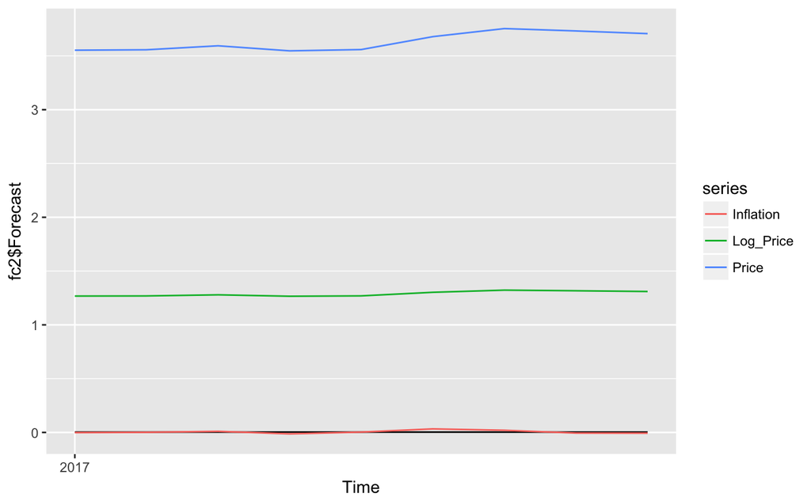

```r
# This function takes in as input our timeseries x, we specify the parameters:
# Forecast Horizon - h
# P,D,Q values for our Arima model
# End date of the train data
# Start date for the test data.
# Column name we want to forecast, in this case it's the "Inflation""
iterative_forecast <- function(x, h = 1, p = 1, d = 0, q = 1, train_end = c(2016,12), test_start = c(2017,1), colname = "Inflation")
{
  train <- window(x, end=train_end)          # create training data
  train <- train[,colname]                   # constrain it to inflation variable
  test <- window(x,start= test_start)        # repeat for test data
  test <- test[,colname]
  n <- length(test) - h + 1                  # create the forecast horizon for the iterative algorithm
  fit <- Arima(train, order = c(p,d,q))      # model initial training data using ARMA(1,1)
  fcmat <- matrix(0, nrow=n, ncol=h)         # create an empty time series to be filled up by forecast data

  for(i in 1:n)
  {
    f <- forecast(train, h = h)$mean                          # perform one step forecast on initial training data
    new <- rbind.xts(train, f)                                # add that forecast to the training data
    new <- ts(new, start = c(1984,1), frequency = 12)         # convert xts object to ts object for modeling
    refit <- Arima(new, order= c(1,0,1))                      # refit model using new training data
    fcmat[i,] <- forecast(refit, h=h)$mean
  }
  my_list <- list("Forecast" = ts(fcmat, start = test_start, frequency = 12), "Fit" = fit, "Refit" = refit)
  return(my_list)    # return forecast in a time series object, initial model and refit model
  }
fc2 <- iterative_forecast(data_ts)  # forecast inflation feature using iterative forecast with one step forecasts added as training data
autoplot(fc2$Forecast) + autolayer(test)     # plot the forecast against test set
```

Using $\hat{y}_{t}$ as training data to forecast $\hat{y}_{t+1}$ leads to a stable one line forecast around the mean of the test set.

##### Direct Forecast

Direct forecasts are much easier to compute on R - With no need to loop over the onstep forecast of the training data. A direct forecast can be computed with the following code:

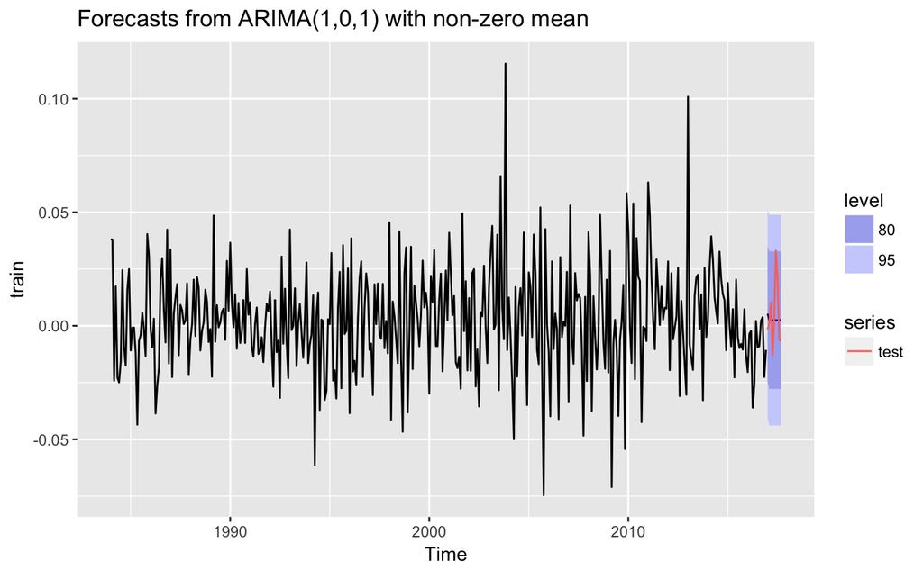

```r
# create train and test data
train <- window(data_ts[,"Inflation"], end = c(2016,12))      # training data being all data up to 2017
test  <- window(data_ts[,"Inflation"], start = c(2017,1))     # test data being all 2017 values
# fit model on train data with forecast horizon being equal to length of test data
fit_direct <- Arima(train, order = c(1,0,1))                  # fit an ARMA(1,1) model
fc_direct <- forecast(fit_direct, h = length(test))
autoplot(fc_direct) + autolayer(test)                   # plot model with confidence intervals
```

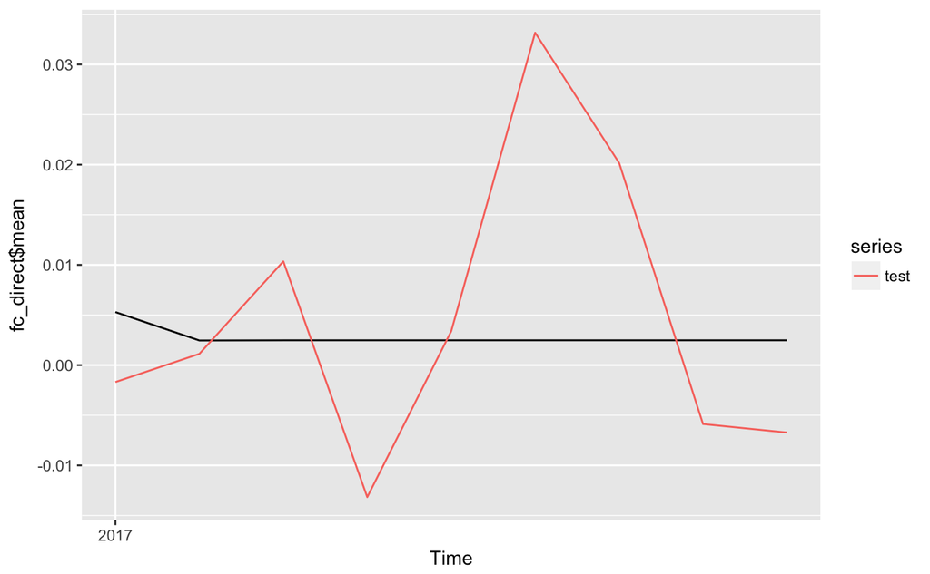

```r
autoplot(fc_direct$mean) + autolayer(test)              # plot point estimations
```

We can see that the direct forecasting technique produced a forecast similar to the iterative model using one step forecasts as training data. Let’s try to compare all of these models.

As a benchmark to compare the $ARMA(p,q)$ models we created, let’s compute an optimized $ARIMA(p,q,d)$ model via the auto.arima() function - auto.arima() does all of the hyperparamter optimization for us.

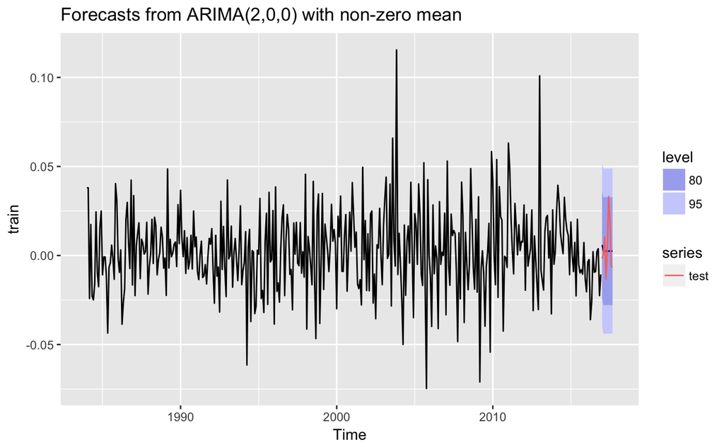

```r
fit_auto <- auto.arima(train, stepwise = FALSE) # we specify stepwise = FALSE so it doesn't take any shortcuts during optimization
fc_auto  <- forecast(fit_auto, h = length(test))
autoplot(fc_auto) + autolayer(test)             # plot model with intervals
```

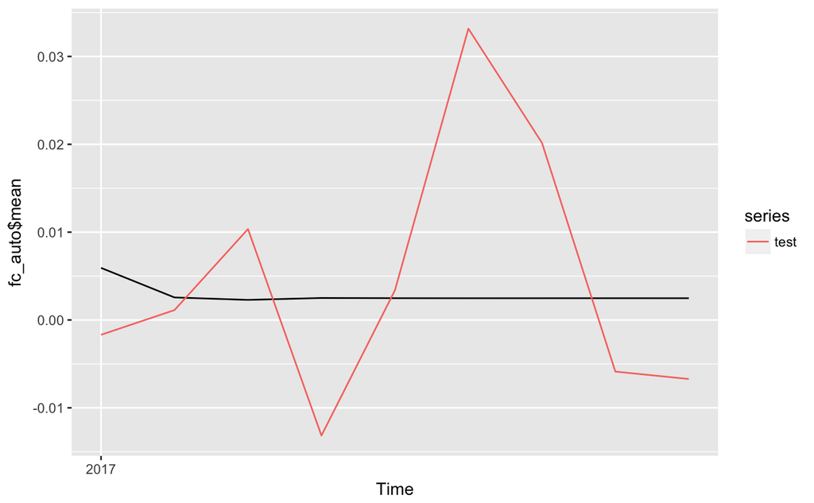

```r
autoplot(fc_auto$mean) + autolayer(test)        # plot point estimation
```

```r
fit_auto       # what was the best model for the data?
```

```
Series: train
ARIMA(2,0,0)            with non-zero mean

Coefficients:
          ar1      ar2    mean
      -0.1671  -0.0507  0.0025
s.e.   0.0504   0.0505  0.0010

sigma^2 estimated as 0.0005443:  log likelihood=927.77
AIC=-1847.55   AICc=-1847.44   BIC=-1831.62
```

We can see that auto.arima() fitted an autoregressive model of order 2 $AR(2)$. Let’s evaluate performances below.

#### 3) Model Comparison

Now we need to compare our model performances, and select the best model. To summarize, we have fitted the following models:

1. $ARMA(1,1)$ that we initially fit in both our iterative models: *fc1$fit & fc2$fit*
2. $ARMA(1,1)$ model with iterative point estimations using training data: *fc1$refit*
3. $ARMA(1,1)$ model with iterative point estimations using forecast data: *fc2$refit*
4. $ARMA(1,1)$ model with direcet forecasting for test data: *fc_direct*
5. $AR(2)$ model which was derived using the auto.arima() model *fc_auto*

Since all the models are part of the $ARIMA(p,d,q)$ family of models, let’s compare the $AICc$ score and check their residuals.

```
    Ljung-Box test

data:  Residuals from ARIMA(1,0,1) with non-zero mean
Q* = 19.864, df = 21, p-value = 0.5299

Model df: 3.   Total lags used: 24
```

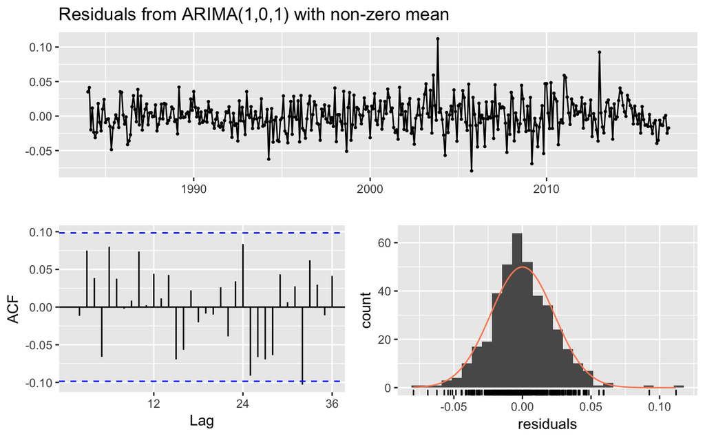

```r
# Check residuals of fc1$fit (same result for fc2$fit)
checkresiduals(fc1$Fit)
```

```
    Ljung-Box test

data:  Residuals from ARIMA(1,0,1) with non-zero mean
Q* = 19.176, df = 21, p-value = 0.5739

Model df: 3.   Total lags used: 24
```

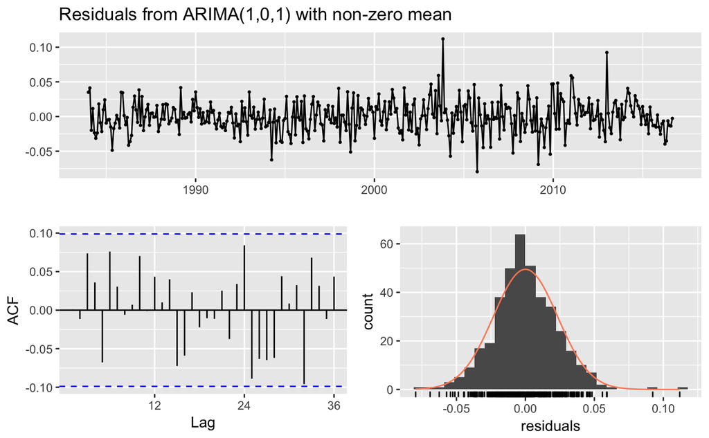

```r
# Check residuals of fc1$refit
checkresiduals(fc1$Refit)
```

```
    Ljung-Box test

data:  Residuals from ARIMA(1,0,1) with non-zero mean
Q* = 19.897, df = 21, p-value = 0.5278

Model df: 3.   Total lags used: 24
```

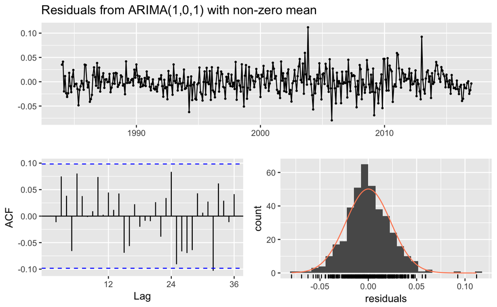

```r
# Check residuals of fc2$refit
checkresiduals(fc2$Refit)
```

```
    Ljung-Box test

data:  Residuals from ARIMA(1,0,1) with non-zero mean
Q* = 19.864, df = 21, p-value = 0.5299

Model df: 3.   Total lags used: 24
```

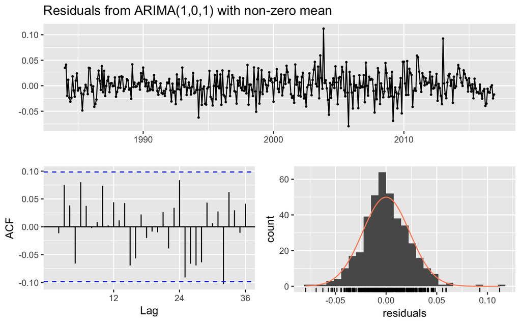

```r
# Check residuals of direct forecast
checkresiduals(fc_direct)
```

```
    Ljung-Box test

data:  Residuals from ARIMA(2,0,0) with non-zero mean
Q* = 19.002, df = 21, p-value = 0.585

Model df: 3.   Total lags used: 24
```

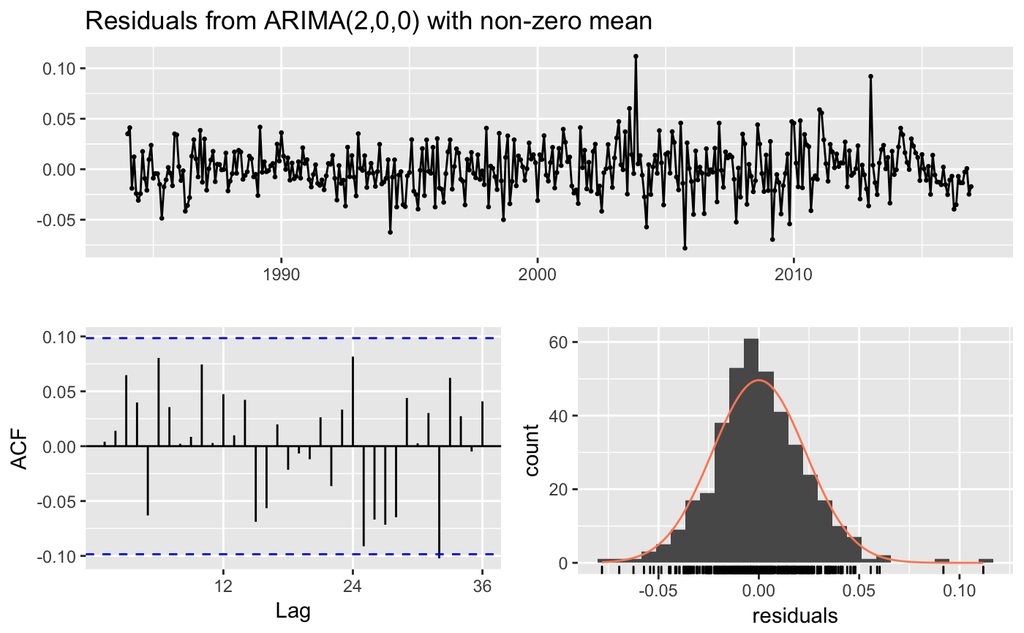

```r
# Check residuals of auto.arima
checkresiduals(fc_auto)
```

We are pleased that all the residuals of these models have acheived some level of sationarity, with all of them having $p-values > 0.05$ in the Ljung-Box test.  
Now let’s compare the $AICc$ score for each model:

```r
my_list2 <- list("Iterated Initial Model" = fc1$Fit$aicc, "Iterated Training Refit" = fc1$Refit$aicc, "Iterated Forecast Refit" = fc2$Refit$aicc, "Direct Forecast" = fc_direct$model$aicc, "Autoregressive(2)" = fc_auto$model$aicc)
print(my_list2)
```

```
$`Iterated Initial Model`
[1] -1846.967

$`Iterated Training Refit`
[1] -1831.616

$`Iterated Forecast Refit`
[1] -1852.628

$`Direct Forecast`
[1] -1846.967

$`Autoregressive(2)`
[1] -1847.445
```

It seems like the Iterated Forecast Refit has the best performance. Let’s compare using the Mincer-Zarnowitz regression.  
The Mincer-Zarnowitz regression is basically regressing actual realized values over the forecast ones - meaning regressing our test data over the forecasts we have produced. The regression should look something like this  
$\alpha_{t+1} = \beta_0 + \beta_1\hat{\alpha}_{t+1}$  
After deriving the regression, we should test for the joint assumption that $\beta_0$ = 0 and $\beta_1 = 1$. *For more details visit this [website](https://eranraviv.com/volatility-forecast-evaluation-in-r/)*

```r
# This is a function that takes in as input the actual realized test data, and the forecast data and returs a linear regression of the test data on the forecast data and it's coefficients, and a linear hypothesis test over the Mincer-Zarnowitz assumptions
MZ_test <- function(test, forecast_data)
{
  MZ_regression = lm(test~forecast_data)
  coefficients  = summary(MZ_regression)$coef
  #hypothesis_test = linearHypothesis(MZ_regression, c("(Intercept) = 0", "forecast_data = 1"))
  mylist <- list("MZ_Model" = MZ_regression, "Coefficients" = coefficients)
  return(mylist)
}
```

```r
# This is a function that takes in as input the actual realized test data, and the forecast data and returs a linear regression of the test data on the forecast data and it's coefficients, and a linear hypothesis test over the Mincer-Zarnowitz assumptions
MZ_test <- function(test, forecast_data)
{
  MZ_regression = lm(test~forecast_data)
  coefficients  = summary(MZ_regression)$coef
  #hypothesis_test = linearHypothesis(MZ_regression, c("(Intercept) = 0", "forecast_data = 1"))
  mylist <- list("MZ_Model" = MZ_regression, "Coefficients" = coefficients)
  return(mylist)
}
MZ_table = list()
MZ_table[1] = linearHypothesis(MZ_test(test, fc1$Forecast)$MZ_Model, c("(Intercept) = 0", "forecast_data = 1"))$F[2]
MZ_table[2] = FALSE
MZ_table[3] = linearHypothesis(MZ_test(test, fc_direct$mean)$MZ_Model, c("(Intercept) = 0", "forecast_data = 1"))$F[2]
MZ_table[4] = linearHypothesis(MZ_test(test, fc_auto$mean)$MZ_Model, c("(Intercept) = 0", "forecast_data = 1"))$F[2]
MZ_table = data.frame(MZ_table)
names(MZ_table)[1] = "fc1"
names(MZ_table)[2] = "fc2"
names(MZ_table)[3] = "fc_direct"
names(MZ_table)[4] = "fc_auto"
row.names(MZ_table)[1] = "F score"
MZ_table = rbind(MZ_table, "Significant" = c("Yes", "Impossible", "Yes", "Yes"))
print(MZ_table)
```

[output not shown]

Since the MZ-Test doesn’t offer any indication on our most performative model (Forecast Data Model *or fc2*), we can run a third test to have a complete overview of performance. The Deibold-Mariano test is a statistical test that compares model performance between two different models.  
Intuitively speaking, it compares the forecast error of a pair of models $(Model \space A, Model \space B)$ and derives a DM statistic out of both forecast errors. If the DM statistic is positive, it means the $Model \space B$ outperforms $Model \space A$, if it is negative, $Model \space A$ outperforms $Model \space B$. Let’s compute the DM statistic for all pairs of models we’ve used thus far and see which one performs better.

```r
# This is a  a Diebold-Mariano test between all the models, with the Iterated Forecast Refit (fc2) model being the benchmark model of comparison
dm_test <- function(test_data, model_1, model_2)  # function that takes in test data, and the forecast values of models to be compared
{
  report <- dm.test((test_data - model_1), (test_data - model_2), alternative = "two.sided", h = 1, power = 2)
  return(report)
}
dm_test1 = dm_test(test, fc1$Forecast, fc2$Forecast) #comparison between Iterated training data model and Iterated forecast data
dm_test2 = dm_test(test, fc1$Forecast, fc_direct$mean) #comparison between Iterated training data model and direct forecast model
dm_test3 = dm_test(test, fc1$Forecast, fc_auto$mean) #comparison between Iterated training data model and auto arima model
dm_test4 = dm_test(test, fc2$Forecast, fc_direct$mean) #comparison between Iterated forecast data model and direct forecast model
dm_test5 = dm_test(test, fc2$Forecast, fc_auto$mean) #comparison between Iterated forecast data model and auto arima model
dm_test6 = dm_test(test, fc_direct$mean, fc_auto$mean) #comparison between direct forecast model and auto arima model
# create a list of DM_values
DM_values = list("Iterated_training/Iterated_forecast:" = dm_test1$statistic, "Iterated_training/Direct_forecast:" = dm_test2$statistic,"Iterated_training/Auto_Arima:" = dm_test3$statistic,"Iterated_Forecast/Direct_Forecast:" = dm_test4$statistic,"Iterated_Forecast/Auto_Arima:" = dm_test5$statistic,"Direct_Forecast/Auto_Arima:" = dm_test6$statistic)
print(DM_values)
```

```
$`Iterated_training/Iterated_forecast:`
      DM
1.013172

$`Iterated_training/Direct_forecast:`
       DM
0.7500039

$`Iterated_training/Auto_Arima:`
       DM
0.7076054

$`Iterated_Forecast/Direct_Forecast:`
        DM
-0.9091932

$`Iterated_Forecast/Auto_Arima:`
       DM
-1.071648

$`Direct_Forecast/Auto_Arima:`
       DM
-1.474749
```

After running the DM tests, we can see that the DM Statistic always falls in favor of the Iterated Forecast Model. Below is a table that postulates the “winner” in the DM test between all of our models.

| Models/Models | Iterated Training Model | Iterated Forecast Model | Direct Forecast Model | Auto Arima Model |
| --- | --- | --- | --- | --- |
| **Iterated Training Model** | X | *Iterated Forecast Model* | Direct Forecast | Auto Arima |
| **Iterated Forecast Model** | *Iterated Forecast Model* | X | *Iterated Forecast Model* | *Iterated Forecast Model* |
| **Direct Forecast Model** | Direct Forecast | *Iterated Forecast Model* | X | Direct Forecast |
| **Auto Arima Model** | Auto Arima | *Iterated Forecast Model* | Direct Forecast Model | X |